# Analiza danych - raport końcowy

K. Ciosek, O. Kanigowski, N. Górczyńska

[figure not shown]

### Analityka Gospodarcza II 2024/2025

$\\ \\ \\ \\ \\$

## 1. Wprowadzenie

### 1.2. Problem

Firma chce zautomatyzować proces kwalifikowania się do pożyczki (w czasie rzeczywistym) w oparciu o dane klienta podane podczas wypełniania wniosku online. Dane te obejmują płeć, stan cywilny, wykształcenie, liczbę osób na utrzymaniu, dochód, kwotę pożyczki, historię kredytową i inne. Aby zautomatyzować ten proces, firma postawiła sobie za cel zidentyfikowanie segmentów klientów, którzy kwalifikują się do otrzymania kwoty pożyczki, aby móc skierować do nich konkretną ofertę. W tym przypadku dostarczono częściowy zestaw danych.

### 1.3. Opis bazy danych

Baza składa się z 13 kolumn, a te z kolei zawierają następujące wartości:

1. **Loan_ID** - indywidualny numer ID każdej obserwacji,
2. **Gender** - informacja, jaka płeć jest przyjęta w danej obserwacji,
3. **Married** - informacja, czy osoba jest w związku małżeńskim,
4. **Dependents** - ilość osób zależnych (finansowo),
5. **Education** - informacja, czy dana osoba ukończyła studia,
6. **Self_Employed** - informacja, czy osoba jest samozatrudniona,
7. **ApplicantIncome** - dochód wnioskodawcy o pożyczkę,
8. **CoapplicantIncome** - dochód współwnioskodawcy o pożyczkę,
9. **LoanAmount** - kwota pożyczki,
10. **Loan_Amount_Term** - okres kredytowania,
11. **Credit_History** - historia kredytowa,
12. **Property_Area** - obszar zamieszkania,
13. **Loan_Status** - informacja, czy udzielono kredytu

## 2. Data Wrangling, Cleasing

Data Wrangling odnosi się do procesu przekształcania, reorganizacji i mapowania surowych danych w użyteczny format gotowy do analizy. Data Cleansing, zwane także czyszczeniem danych, odnosi się do procesu identyfikacji i usuwania błędów, niespójności oraz niekompletnych informacji w zbiorach danych. Celem tego procesu jest poprawa jakości danych, co jest kluczowe dla analizy oraz podejmowania trafnych decyzji opartych na danych.

### 2.1 Obliczanie NA

```r
#podstawowe statystyki
summary(data)
```

```
##    Loan_ID             Gender            Married           Dependents
##  Length:614         Length:614         Length:614         Length:614
##  Class :character   Class :character   Class :character   Class :character
##  Mode  :character   Mode  :character   Mode  :character   Mode  :character
##
##
##
##
##   Education         Self_Employed      ApplicantIncome CoapplicantIncome
##  Length:614         Length:614         Min.   :  150   Min.   :    0
##  Class :character   Class :character   1st Qu.: 2878   1st Qu.:    0
##  Mode  :character   Mode  :character   Median : 3812   Median : 1188
##                                        Mean   : 5403   Mean   : 1621
##                                        3rd Qu.: 5795   3rd Qu.: 2297
##                                        Max.   :81000   Max.   :41667
##
##    LoanAmount    Loan_Amount_Term Credit_History   Property_Area
##  Min.   :  9.0   Min.   : 12      Min.   :0.0000   Length:614
##  1st Qu.:100.0   1st Qu.:360      1st Qu.:1.0000   Class :character
##  Median :128.0   Median :360      Median :1.0000   Mode  :character
##  Mean   :146.4   Mean   :342      Mean   :0.8422
##  3rd Qu.:168.0   3rd Qu.:360      3rd Qu.:1.0000
##  Max.   :700.0   Max.   :480      Max.   :1.0000
##  NA's   :22      NA's   :14       NA's   :50
##  Loan_Status
##  Length:614
##  Class :character
##  Mode  :character
##
##
##
##
```

```r
#struktura danych
str(data)
```

```
## 'data.frame':    614 obs. of  13 variables:
##  $ Loan_ID          : chr  "LP001002" "LP001003" "LP001005" "LP001006" ...
##  $ Gender           : chr  "Male" "Male" "Male" "Male" ...
##  $ Married          : chr  "No" "Yes" "Yes" "Yes" ...
##  $ Dependents       : chr  "0" "1" "0" "0" ...
##  $ Education        : chr  "Graduate" "Graduate" "Graduate" "Not Graduate" ...
##  $ Self_Employed    : chr  "No" "No" "Yes" "No" ...
##  $ ApplicantIncome  : int  5849 4583 3000 2583 6000 5417 2333 3036 4006 12841 ...
##  $ CoapplicantIncome: num  0 1508 0 2358 0 ...
##  $ LoanAmount       : int  NA 128 66 120 141 267 95 158 168 349 ...
##  $ Loan_Amount_Term : int  360 360 360 360 360 360 360 360 360 360 ...
##  $ Credit_History   : int  1 1 1 1 1 1 1 0 1 1 ...
##  $ Property_Area    : chr  "Urban" "Rural" "Urban" "Urban" ...
##  $ Loan_Status      : chr  "Y" "N" "Y" "Y" ...
```

```r
#obliczanie liczby NA (brakujących wartości) uwzględniając "puste ciągi"
count_na <- function(x) {
  sum(is.na(x) | x == "" | x == " ")
}
na_count <- sapply(data, count_na)
na_count
```

```
##           Loan_ID            Gender           Married        Dependents
##                 0                13                 3                15
##         Education     Self_Employed   ApplicantIncome CoapplicantIncome
##                 0                32                 0                 0
##        LoanAmount  Loan_Amount_Term    Credit_History     Property_Area
##                22                14                50                 0
##       Loan_Status
##                 0
```

Tworzona jest funkcja count_na(), która: Sprawdza, czy wartość w danej kolumnie to NA (brak wartości), sprawdza, czy wartość to pusty ciąg “” lub spacja ” “, traktując je jako brakujące. Sumuje wszystkie brakujące wartości w danej kolumnie.

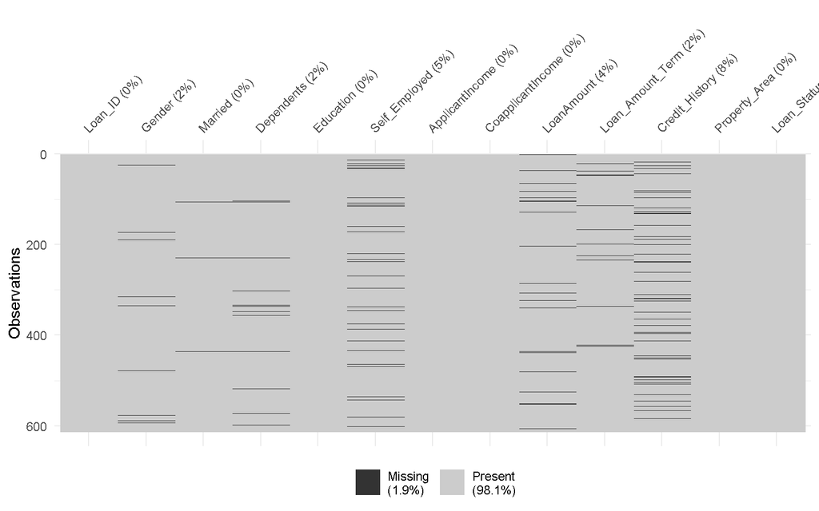

```r
#zamiana pustych ciagow na NA
data[data == ""] <- NA
data[data == " "] <- NA
#wizualizacja braków danych
vis_miss(data)
```

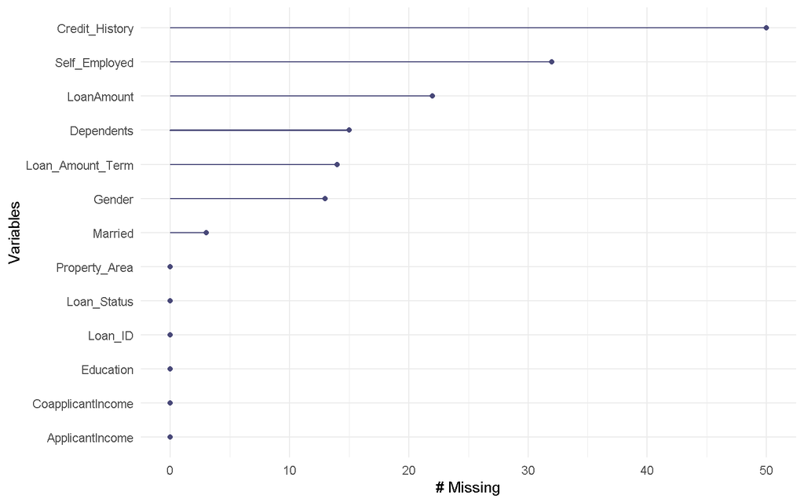

```r
gg_miss_var(data)
```

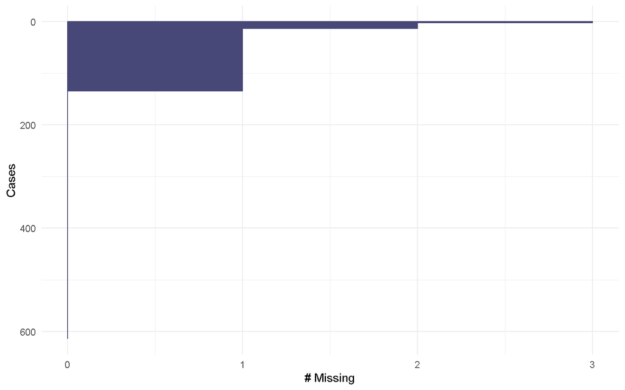

```r
gg_miss_case(data)
```

vis_miss: Tworzy wizualizację brakujących wartości w całym zbiorze danych. gg_miss_var: Tworzy wykres przedstawiający liczbę braków danych w poszczególnych kolumnach. gg_miss_case: Wizualizuje liczbę braków danych w poszczególnych wierszach (rekordach).

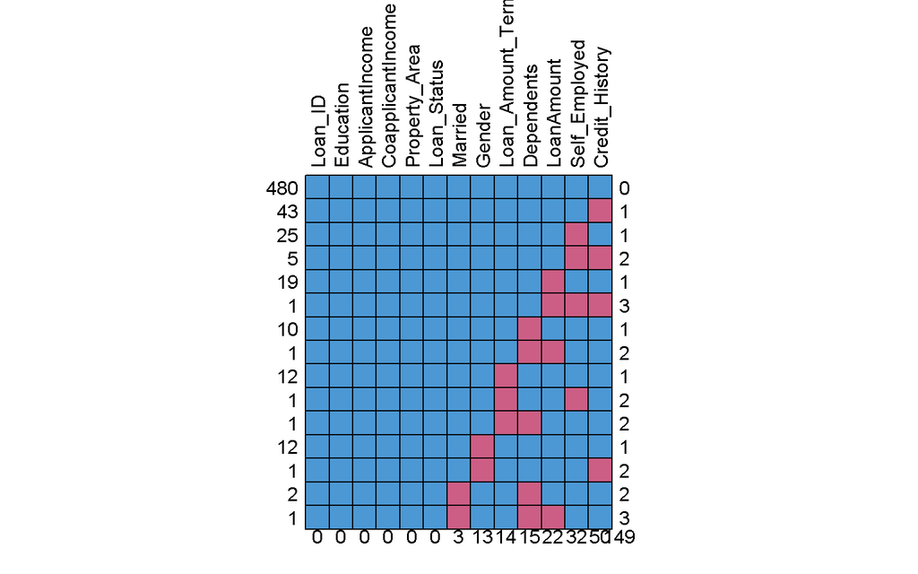

```
##     Loan_ID Education ApplicantIncome CoapplicantIncome Property_Area
## 480       1         1               1                 1             1
## 43        1         1               1                 1             1
## 25        1         1               1                 1             1
## 5         1         1               1                 1             1
## 19        1         1               1                 1             1
## 1         1         1               1                 1             1
## 10        1         1               1                 1             1
## 1         1         1               1                 1             1
## 12        1         1               1                 1             1
## 1         1         1               1                 1             1
## 1         1         1               1                 1             1
## 12        1         1               1                 1             1
## 1         1         1               1                 1             1
## 2         1         1               1                 1             1
```

[output cut: 36 more lines]

```r
#wzorce braków danych
md.pattern(data, plot = TRUE, rotate.names = TRUE)
```

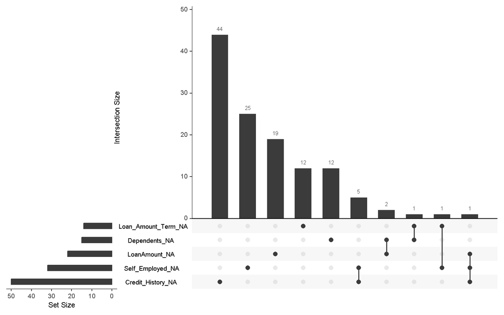

```r
gg_miss_upset(data)
```

md.pattern analizuje wzorce brakujących danych i prezentuje je graficznie. gg_miss_upset tworzy wykres upset, który pokazuje, które kombinacje braków danych są najczęstsze.

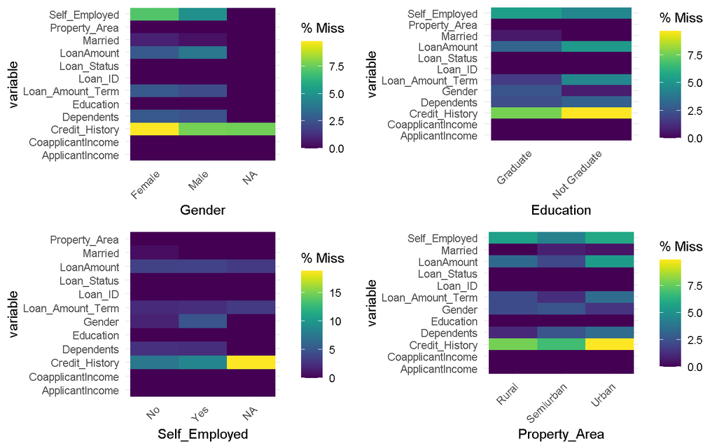

Podsumowując, kod identyfikuje i liczy brakujące wartości, uwzględniając puste ciągi. Przygotowuje dane, zastępując puste wartości NA. Wizualizuje rozkład braków danych w zbiorze (kolumny, wiersze, wzorce braków). Analizuje wpływ zmiennych kategorycznych na występowanie braków danych.

Braki danych uzupełniono metodą mice, natomiast braki wartoście Married zastąpiono medianą.

### 2.2 Identyfikacja unikatowych wartości

```
##                   unikalne_wartosci
## Loan_ID                         614
## Gender                            2
## Married                           2
## Dependents                        4
## Education                         2
## Self_Employed                     2
## ApplicantIncome                 505
## CoapplicantIncome               287
## LoanAmount                      203
## Loan_Amount_Term                 10
## Credit_History                    2
## Property_Area                     3
## Loan_Status                       2
```

```
##      odpowiedzi liczba_obserwacji        kategorie
## 1        Female               112           Gender
## 2          Male               489           Gender
## 3            No               213          Married
## 4           Yes               398          Married
## 5             0               345       Dependents
## 6             1               102       Dependents
## 7             2               101       Dependents
## 8            3+                51       Dependents
## 9      Graduate               480        Education
## 10 Not Graduate               134        Education
## 11           No               500    Self_Employed
## 12          Yes                82    Self_Employed
## 13            0                89   Credit_History
## 14            1               475   Credit_History
## 15        Rural               179    Property_Area
## 16    Semiurban               233    Property_Area
## 17        Urban               202    Property_Area
## 18            N               192      Loan_Status
## 19            Y               422      Loan_Status
## 20           12                 1 Loan_Amount_Term
## 21           36                 2 Loan_Amount_Term
## 22           60                 2 Loan_Amount_Term
## 23           84                 4 Loan_Amount_Term
## 24          120                 3 Loan_Amount_Term
## 25          180                44 Loan_Amount_Term
## 26          240                 4 Loan_Amount_Term
## 27          300                13 Loan_Amount_Term
## 28          360               512 Loan_Amount_Term
## 29          480                15 Loan_Amount_Term
```

```
##                       class
## Loan_ID           character
## Gender            character
## Married           character
## Dependents        character
## Education         character
## Self_Employed     character
## ApplicantIncome     integer
## CoapplicantIncome   numeric
## LoanAmount          integer
## Loan_Amount_Term    integer
## Credit_History      integer
## Property_Area     character
## Loan_Status       character
```

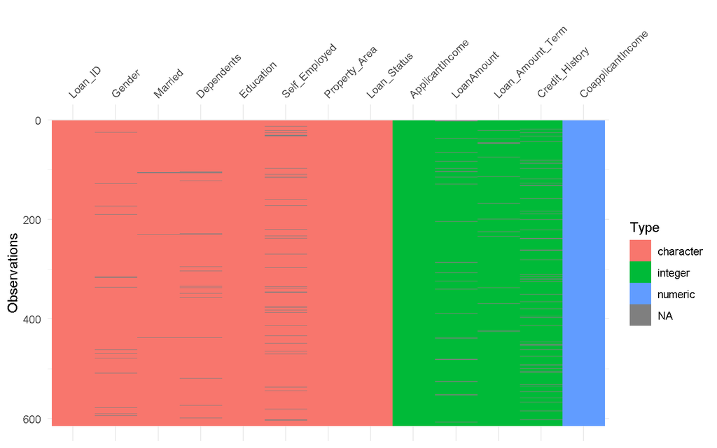

Dla określonych kolumn kategorycznych (np. Gender, Married, Education, Loan_Status) tworzona jest tabela częstości wartości. Tworzony jest zbiorczy data.frame, który zawiera liczbę wystąpień każdej wartości w każdej analizowanej kolumnie.

### 2.4. Data Cleasing

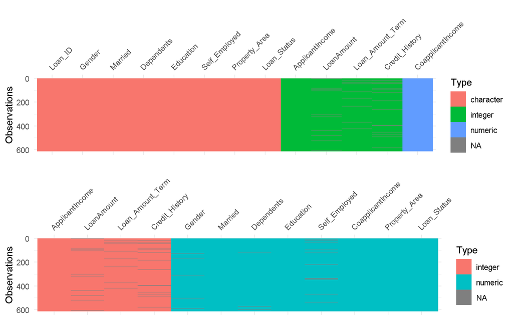

Tworzona jest funkcja map_to_numeric, która konwertuje zmienne kategoryczne na wartości numeryczne na podstawie zdefiniowanego mapowania. Zmienne takie jak Gender, Married, Education, Self_Employed, Property_Area, Loan_Status są zamieniane na wartości liczbowe (np. Male = 1, Female = 0). Kod ten przekształca surowe dane w ustrukturyzowaną formę, gotową do analizy i modelowania. Usuwa zbędne wartości, standardyzuje formaty.

### 2.5. Podział klientów

W celu rozwiązania stojącego przed danymi problemu - wyodrębnienia klientów kwalifikujących się do uzyskania pożyczki w celu wysłania im odpowiedniej oferty, zaporponowano następujące rozwiązania:

1. Podział ze względu na dochody gospodarstwa domowego w zależności od ilość osób zależnych
2. Podział za pomocą algorytmnu klastrowania

Linia podziału w punkcie pierwszym przebiegała według najmniejszej wartości odstającej, klientów powyżej tej wartości zaliczono do klientów **premium**, natomiast poniżej - do klientów typu **basic**.

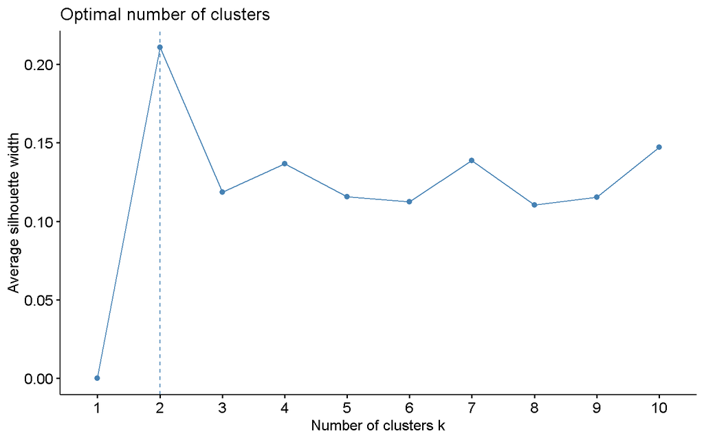

```r
# Normalizacja danych
s_data <- scale(data)

# Wybór optymalnej liczby klastrów
fviz_nbclust(s_data, kmeans, method = "silhouette")
```

Jak widać na powyższym wykresie, za pomocą metody k-średnich znaleziono optymalną liczbę klastrów (grup) na które można podzielić potencjalnych kredytobiorców która wynosi 2.

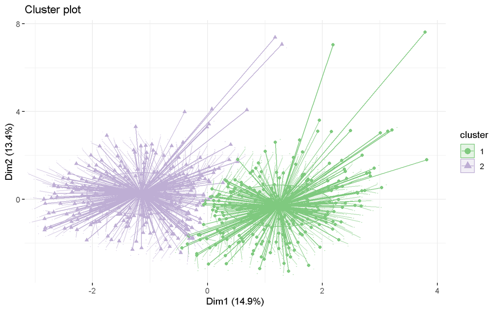

```r
# Klasteryzacja
clusters <- kmeans(s_data, centers = 2, nstart = 25)

fviz_cluster(clusters, data = s_data,
             palette = "Accent",
             ellipse.type = "euclid",
             star.plot = TRUE,
             repel = TRUE,
             ggtheme = theme_minimal(),
             labelsize = 0)
```

Na powyższym wykresie widoczna jest wizualizacja rozrzutu klastrów.

```r
data$Cluster <- as.factor(clusters$cluster)

# Statystyki opisowe dla każdego klastra
summary_stat <- data %>%
  group_by(Cluster) %>%
  summarise(across(everything(), list(mean = ~mean(.), sd = ~sd(.), median = ~median(.),
                                      min = ~min(.), max = ~max(.), n = ~length(.)),
                   .names = "{col}_{fn}"))

summary_statistics <- summary_stat[,14:ncol(summary_stat)]
print(summary_statistics)
```

```
## # A tibble: 2 × 72
##   Gender_mean Gender_sd Gender_median Gender_min Gender_max Gender_n
##         <dbl>     <dbl>         <int>      <int>      <int>    <int>
## 1       0.814     0.390             1          0          1      295
## 2       0.809     0.394             1          0          1      319
## # ℹ 66 more variables: Married_mean <dbl>, Married_sd <dbl>,
## #   Married_median <int>, Married_min <int>, Married_max <int>,
## #   Married_n <int>, Dependents_mean <dbl>, Dependents_sd <dbl>,
## #   Dependents_median <int>, Dependents_min <int>, Dependents_max <int>,
## #   Dependents_n <int>, Education_mean <dbl>, Education_sd <dbl>,
## #   Education_median <int>, Education_min <int>, Education_max <int>,
## #   Education_n <int>, Self_Employed_mean <dbl>, Self_Employed_sd <dbl>, …
```

- Demografia: Większość to mężczyźni (80%), osoby zamężne (64%) i wykształcone (76%).
- Zatrudnienie: Tylko 15% jest samozatrudnionych.
- Finanse: Średni dochód wnioskodawcy to 5624 z dużą rozpiętością (min. 210, max. 81 000).
- Kredyt: Średnia kwota kredytu wynosi 149 tys., a okres spłaty 341 miesięcy.

- Demografia: Nieco większy udział kobiet (ok. 20%), większy odsetek osób zamężnych (66%) i wykształconych (80%).
- Zatrudnienie: Samozatrudnieni stanowią 13% grupy.
- Finanse: Średni dochód wnioskodawcy jest niższy (5188), a maksymalna wartość dochodu to 51 763.
- Kredyt: Średnia kwota kredytu jest nieco niższa (143 tys.), a okres spłaty podobny (342 miesiące).

Klaster 1 charakteryzuje się wyższymi dochodami i większą różnorodnością dochodów, podczas gdy klaster 2 ma nieco wyższy udział osób wykształconych i zamężnych, ale niższe dochody.

## 3. Wizualizacja danych

### 3.1. Wykesy puedłkowe

Każdy **wykres pudełkowy** przedstawia rozkład dochodu w gospodarstwie domowym (**HouseholdIncome**) w zależności od miejsca zamieszkania klientów. Pierwszy wykres pokazuje, jak dochody kształtują się w różnych lokalizacjach dla wszystkich klientów, natomiast drugi dodatkowo rozróżnia klientów **Basic**, a trzeci **Premium**. Taka wizualizacja pozwala lepiej zrozumieć, jak dochody różnią się w różnych obszarach oraz jak przedstawiają się w poszczególnych grupach klientów.

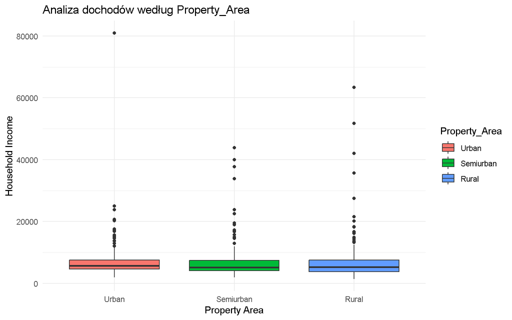

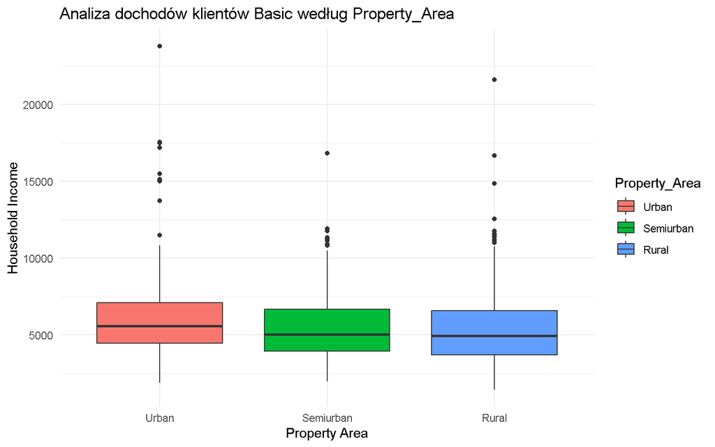

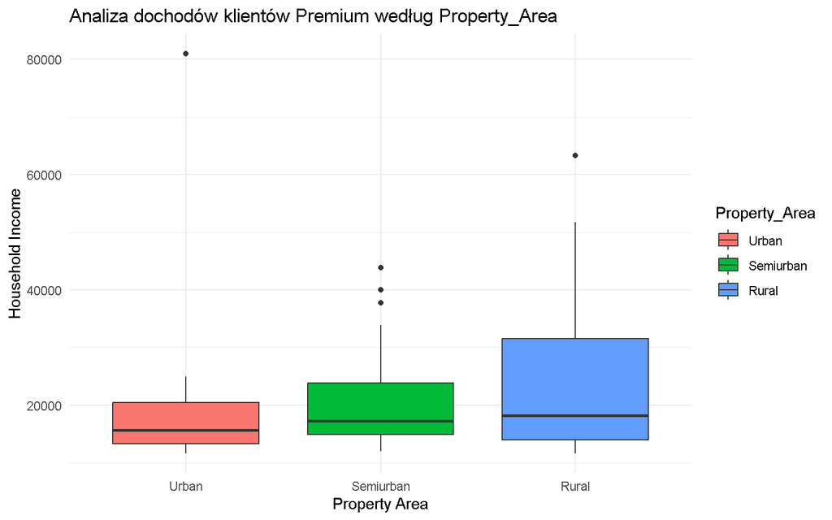

Klienci **Premium** mają **wyższe i bardziej zróżnicowane dochody** niż klienci Basic, szczególnie w obszarach **wiejskich**. Największa **zmienność dochodów** w obu grupach występuje w rejonach **wiejskich**.

### 3.2. Wykresy słupkowe

Na **wykresach słupkowych** zaprezentujemy zmienne: Gender, Married, Dependents oraz Education.

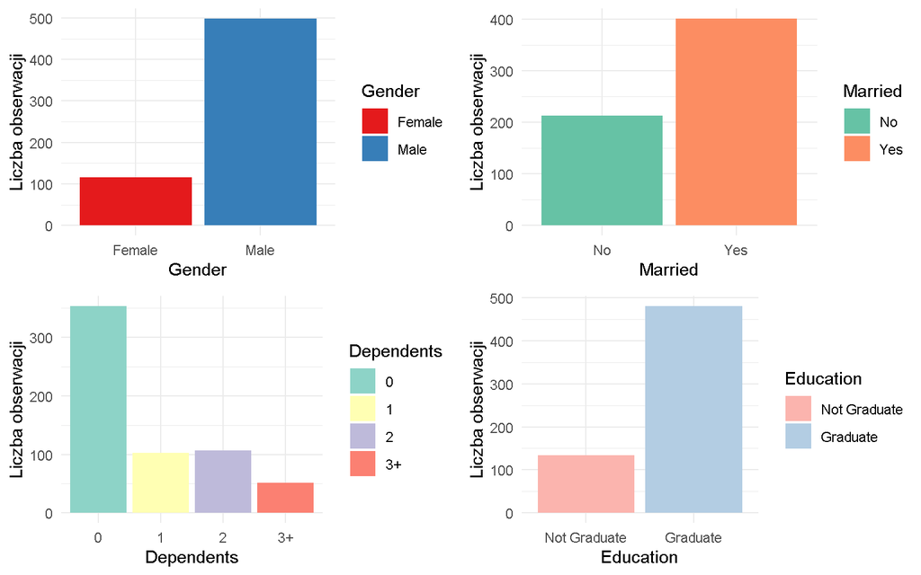

Z powyższych wykresów możemy wywnioskować, że w danych dużo większy udział mają **mężczyźni** niż kobiety. Więcej jest także osób **w związku małżeńskim** niż singli, zdecydowaną większością są osoby, które **nie mają pod sobą osób zależnych** oraz o kredyt aplikuje więcej osób ze **skończonymi studiami**.

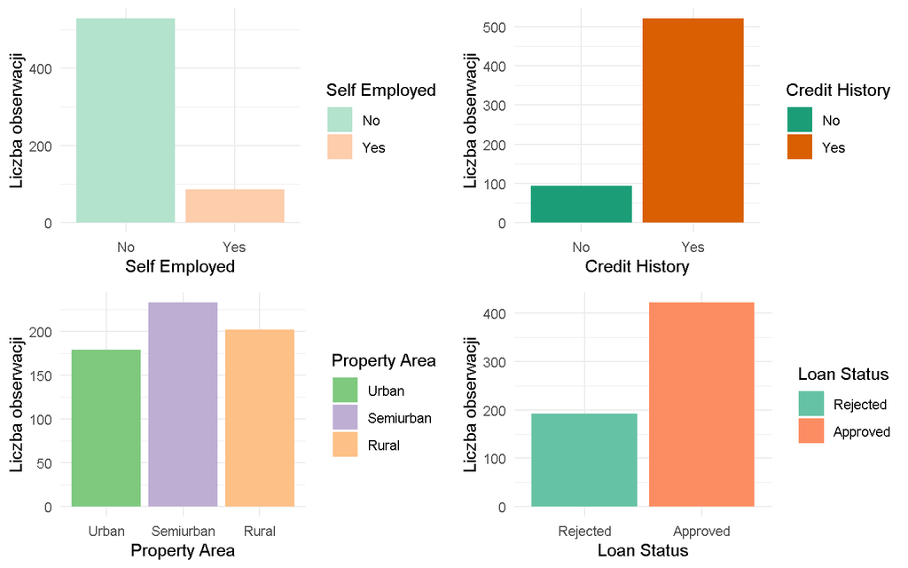

## 4. Analiza opisowa

Pierwszym etapem analiz wszelkiego typu danych jest ich **analiza opisowa**. Pozwala ona lepiej zrozumieć dane oraz wyciągnąć odpowienie wnioski.

### 4.1. Statystyki opisowe

**Statystyki opisowe** pomagają szybko zrozumieć, jakie wartości dominują, jak bardzo dane są zróżnicowane i czy występują jakieś nietypowe przypadki. Dzięki nim mogliśmy np. sprawdzić, jaki jest przeciętny dochód wnioskodawcy, jak bardzo dochody różnią się między aplikantami, albo czy w danych są osoby, które odstają od reszty.

**Rozkład IncomePerDependent wg Loan_Status**

| **Zmienna** | **0** N = 192 | **1** N = 422 | **p-value**<sup>1</sup> |
| --- | --- | --- | --- |
| Przychód na jedną osobę w gospodarstwie domowym |  |  | 0.94 |
| N Non-missing | 192 | 422 |  |
| Mean | 6,106 | 5,763 |  |
| SD | 5,302 | 5,090 |  |
| Median (Q1, Q3) | 4,699 (2,908, 7,131) | 4,730 (3,270, 6,400) |  |
| Min, Max | 610, 35,673 | 942, 63,337 |  |

<sup>1</sup> Wilcoxon rank sum test

Tabela przedstawia **rozkład przychodu na jedną osobę w gospodarstwie domowym** w podziale na **status kredytowy**, gdzie **0** oznacza osoby, którym kredytu nie przyznano (*N = 192*), a **1** oznacza osoby, które otrzymały kredyt (*N = 422*).

### 4.2. Korelacja

**Korelacja** pokazuje, czy i jak mocno dwie zmienne są ze sobą powiązane.

U nas wygląda to następująco:

```
##                            X.2         X.1           X       Gender
## X.2                 1.00000000  1.00000000  1.00000000 -0.031900583
## X.1                 1.00000000  1.00000000  1.00000000 -0.031900583
## X                   1.00000000  1.00000000  1.00000000 -0.031900583
## Gender             -0.03190058 -0.03190058 -0.03190058  1.000000000
## Married            -0.01601317 -0.01601317 -0.01601317  0.356275359
## Dependents          0.05614104  0.05614104  0.05614104  0.179851514
## Education          -0.03944197 -0.03944197 -0.03944197 -0.053546793
## Self_Employed       0.02208120  0.02208120  0.02208120 -0.021008857
## ApplicantIncome     0.01692515  0.01692515  0.01692515  0.032350855
## CoapplicantIncome   0.03921107  0.03921107  0.03921107  0.077678416
## LoanAmount          0.03050557  0.03050557  0.03050557  0.081060177
## Loan_Amount_Term   -0.02900425 -0.02900425 -0.02900425 -0.076187985
## Credit_History     -0.03631300 -0.03631300 -0.03631300  0.002785175
## Property_Area      -0.15541641 -0.15541641 -0.15541641 -0.024612939
## Loan_Status         0.01177341  0.01177341  0.01177341  0.006519051
## HouseholdIncome     0.03377445  0.03377445  0.03377445  0.065793648
## IncomePerDependent  0.02071706  0.02071706  0.02071706  0.043931212
## type_of_client      0.04621324  0.04621324  0.04621324 -0.014285200
##                         Married   Dependents   Education Self_Employed
## X.2                -0.016013167  0.056141038 -0.03944197   0.022081201
## X.1                -0.016013167  0.056141038 -0.03944197   0.022081201
## X                  -0.016013167  0.056141038 -0.03944197   0.022081201
## Gender              0.356275359  0.179851514 -0.05354679  -0.021008857
## Married             1.000000000  0.337886897 -0.01230438   0.008221324
## Dependents          0.337886897  1.000000000 -0.07560693   0.056368651
## Education          -0.012304383 -0.075606925  1.00000000   0.020095121
## Self_Employed       0.008221324  0.056368651  0.02009512   1.000000000
## ApplicantIncome     0.051708376  0.111009718  0.14076028   0.166062451
## CoapplicantIncome   0.075947672  0.026996631  0.06228983  -0.021494459
## LoanAmount          0.145275385  0.155004331  0.16877015   0.125530163
## Loan_Amount_Term   -0.104822514 -0.090575390  0.06885308  -0.037420834
## Credit_History      0.003714357 -0.062706146  0.06006666  -0.010867713
## Property_Area       0.004256547  0.004891355  0.06524332  -0.031141695
## Loan_Status         0.091477825 -0.003569252  0.08588391  -0.021333458
## HouseholdIncome     0.083319148  0.117231962  0.16136246   0.147334546
## IncomePerDependent -0.006017892 -0.238778682  0.17105747   0.166668596
## type_of_client     -0.027929057 -0.049859848  0.11409227   0.128301281
##                    ApplicantIncome CoapplicantIncome  LoanAmount
## X.2                    0.016925154        0.03921107  0.03050557
```

[output cut: 40 more lines]

```
## Gender                 0.065793648        0.043931212    -0.01428520
## Married                0.083319148       -0.006017892    -0.02792906
## Dependents             0.117231962       -0.238778682    -0.04985985
## Education              0.161362460        0.171057467     0.11409227
## Self_Employed          0.147334546        0.166668596     0.12830128
## ApplicantIncome        0.893037294        0.746487999     0.62287490
## CoapplicantIncome      0.342780824        0.291592773     0.20435018
## LoanAmount             0.621409812        0.511905650     0.46681332
## Loan_Amount_Term      -0.071647897       -0.041161202    -0.02954493
## Credit_History        -0.050539794        0.006993410    -0.04283670
## Property_Area         -0.004218254        0.019759980     0.01937862
## Loan_Status           -0.031270779       -0.030840148    -0.06268708
## HouseholdIncome        1.000000000        0.838191812     0.68174288
## IncomePerDependent     0.838191812        1.000000000     0.73818311
## type_of_client         0.681742882        0.738183114     1.00000000
```

Zdecydowaliśmy się ograniczyć korelacje, aby ukazywały się tylko te **od 0,5 do 1** (korelacja silna).

```
##                  Var1               Var2      Freq
## 1                 X.1                X.2 1.0000000
## 2  IncomePerDependent    HouseholdIncome 0.9527593
## 3      type_of_client IncomePerDependent 0.9489643
## 4     HouseholdIncome    ApplicantIncome 0.9487066
## 5      type_of_client    HouseholdIncome 0.9239404
## 6  IncomePerDependent    ApplicantIncome 0.9000457
## 7      type_of_client    ApplicantIncome 0.8834059
## 8     HouseholdIncome         LoanAmount 0.8708846
## 9          LoanAmount    ApplicantIncome 0.8409786
## 10        Loan_Status     Credit_History 0.8099601
## 11 IncomePerDependent         LoanAmount 0.7950181
## 12     type_of_client         LoanAmount 0.7883677
## 13            Married             Gender 0.5964911
## 14         Dependents            Married 0.5507486
```

W celu bardziej przejrzystego przedstawienia danych, prezentujemy naszą **macierz korelacji**:

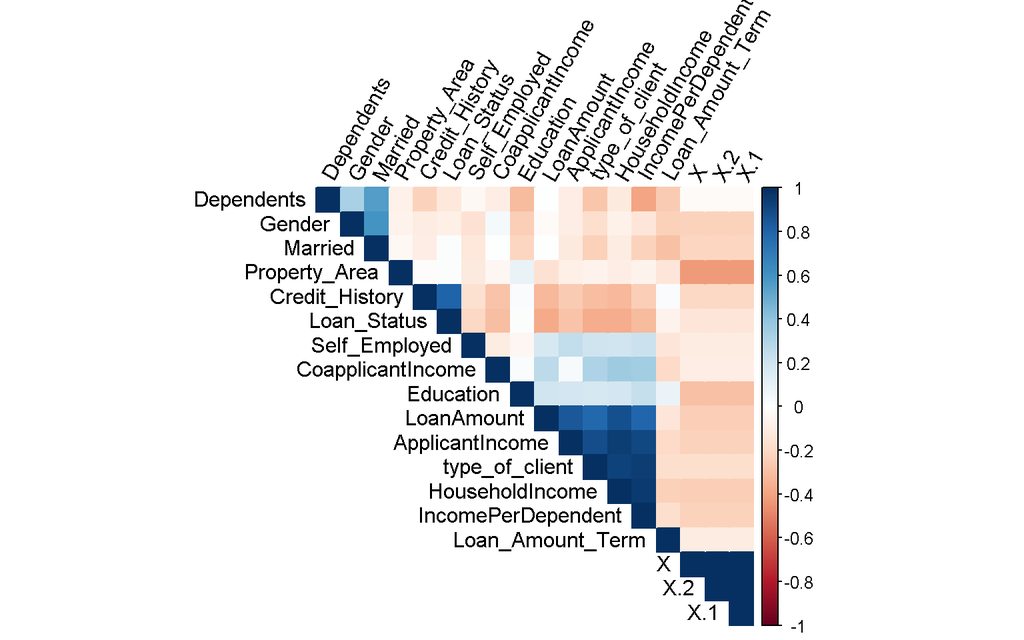

Stąd od razu widzimy, które zmienne są ze sobą silnie skorelowane, a które słabiej.

## 5. Wnioskowanie (testy statystyczne)

Wnioskowanie statystyczne to proces podejmowania decyzji lub formułowania wniosków na podstawie danych. W ramach projektu podjęto próbę zdefinowania wzajemnych zależności pomiędzy zmiennymi opisującymi osoby wnioskujące o kredyt, w kontekście finalnej decyzji banku o udzieleniu pożyczki, lub też decyzji odmownej.

### 5.1. Model regresji logistycznej

W celu przeprowadzenia wnioskowania wykorzystano model regresji logistycznej (logit) - tóry jest używany do analizy zmiennych zależnych o charakterze binarnym, takich jaką jest zmienna opisująca decyzję o przyznaniu pożyczki.

```r
logit1 <- glm(Loan_Status ~ Married + ApplicantIncome + CoapplicantIncome +Dependents + Education + LoanAmount + Credit_History,
              data = data, family = binomial)
summary(logit1)
```

```
##
## Call:
## glm(formula = Loan_Status ~ Married + ApplicantIncome + CoapplicantIncome +
##     Dependents + Education + LoanAmount + Credit_History, family = binomial,
##     data = data)
##
## Coefficients:
##                     Estimate Std. Error z value Pr(>|z|)
## (Intercept)       -2.619e+00  4.364e-01  -6.002 1.95e-09 ***
## Married            6.040e-01  2.315e-01   2.609  0.00909 **
## ApplicantIncome    1.183e-05  2.177e-05   0.543  0.58681
## CoapplicantIncome -3.473e-05  3.879e-05  -0.895  0.37066
## Dependents         1.975e-02  1.148e-01   0.172  0.86344
## Education          4.575e-01  2.496e-01   1.833  0.06684 .
## LoanAmount        -1.997e-03  1.531e-03  -1.304  0.19217
## Credit_History     3.502e+00  3.568e-01   9.816  < 2e-16 ***
## ---
## Signif. codes:  0 '***' 0.001 '**' 0.01 '*' 0.05 '.' 0.1 ' ' 1
##
## (Dispersion parameter for binomial family taken to be 1)
##
##     Null deviance: 762.89  on 613  degrees of freedom
## Residual deviance: 582.68  on 606  degrees of freedom
## AIC: 598.68
##
## Number of Fisher Scoring iterations: 4
```

Dla utworzonego modelu zmienną objaśniającą jest Loan_Status informujący o decyzji przyznanie pożyczki, natomiast zmienne objaśniające to pozostałe dostępne informacje o potencjalnych kredytobiorcach.

```r
logit2 <- glm(Loan_Status ~ Married + Credit_History,
              data = data, family = binomial)
summary(logit2)
```

```
##
## Call:
## glm(formula = Loan_Status ~ Married + Credit_History, family = binomial,
##     data = data)
##
## Coefficients:
##                Estimate Std. Error z value Pr(>|z|)
## (Intercept)     -2.5127     0.3705  -6.782 1.18e-11 ***
## Married          0.5519     0.2119   2.605  0.00919 **
## Credit_History   3.5109     0.3543   9.910  < 2e-16 ***
## ---
## Signif. codes:  0 '***' 0.001 '**' 0.01 '*' 0.05 '.' 0.1 ' ' 1
##
## (Dispersion parameter for binomial family taken to be 1)
##
##     Null deviance: 762.89  on 613  degrees of freedom
## Residual deviance: 588.29  on 611  degrees of freedom
## AIC: 594.29
##
## Number of Fisher Scoring iterations: 4
```

```r
OR <- exp(logit2$coefficients)
print(OR)
```

```
##    (Intercept)        Married Credit_History
##     0.08104677     1.73653607    33.47855312
```

W ramach drugie modelu przyjęto jako zmienne objaśniające dwie zmienne o największej istotności statystycznej w stosunku do wszystkich danych. Można stąd wysunąć wniosek, że zmiennymi o największym wpływie na decyzję o przyzaniu kredytu są zmienne mówiące o stanie cywilnym oraz hisotrii kredytowej.

*Zakładając, że tylko te dwie wartości determinowałyby decyzję:*

- bycie w zwiazku malzenskim zwieksza szanse na otrzymanie kredytu o 73%.
- natomiast pozytywna historia kredytowa zwieksza szanse na otrzymanie kredytu az o 3248%

### 5.2. Wizualizacja testów statystycznych

Wszystkie analizowane zmienne są istotne statystycznie przy poziomie istotności 0.05.

**Historia kredytowa:**

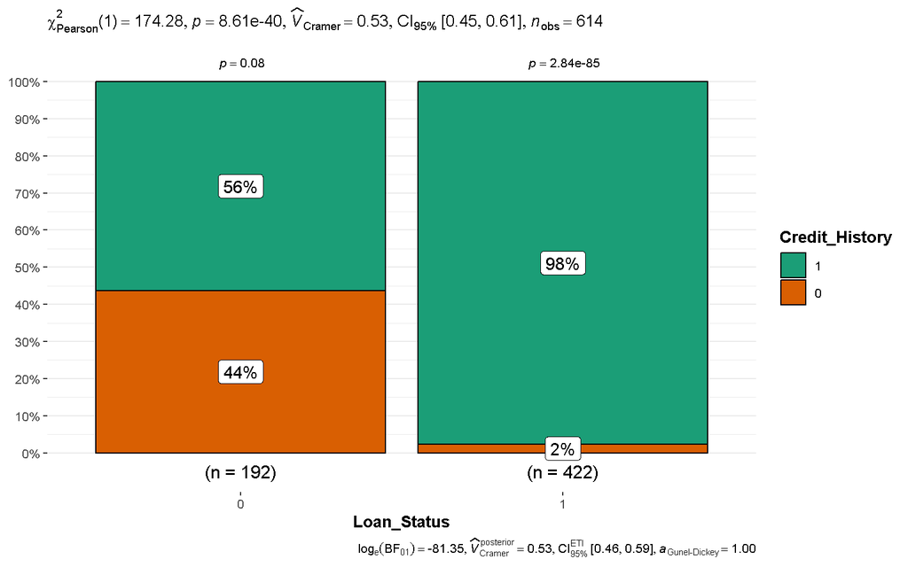

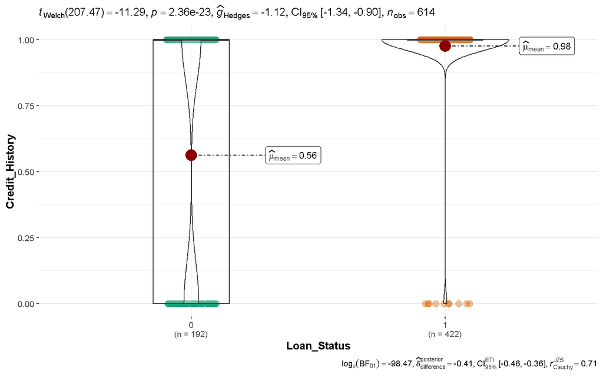

**Stan cywilny:**

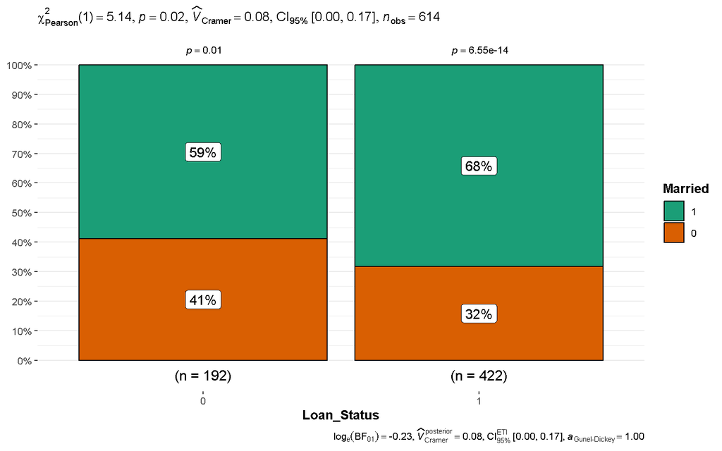

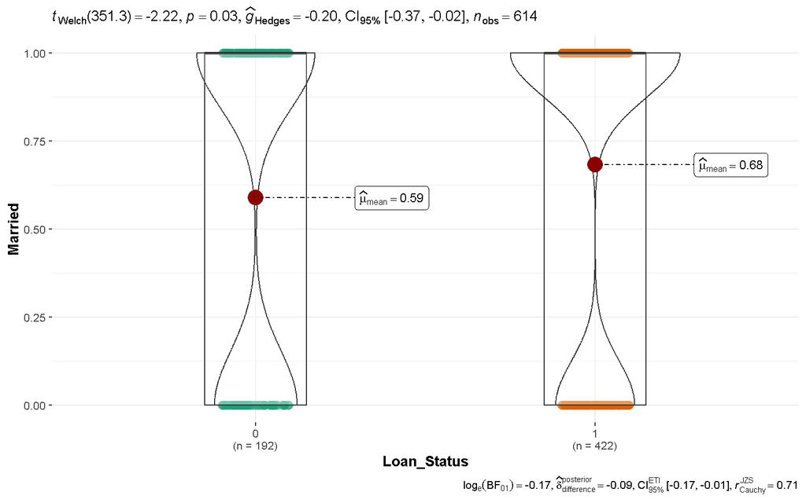

**Poziom edukacji:**

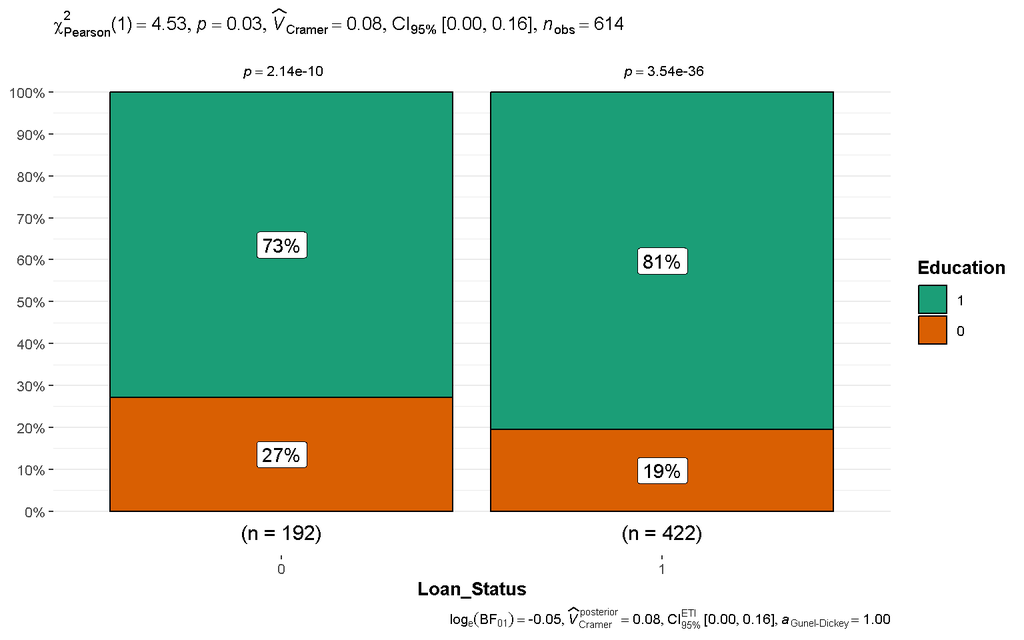

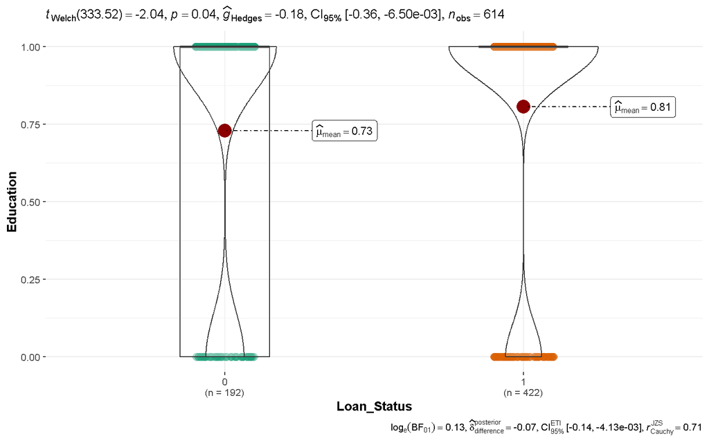

## 6. Podsumowanie i wnioski końcowe

W ramach przeprowadzonej analizy danych zastosowano szereg technik przetwarzania, wizualizacji, analizy opisowej oraz wnioskowania statystycznego, które pozwoliły na dogłębne zrozumienie zależności między zmiennymi a decyzją o przyznaniu pożyczki.

- Pierwszym etapem pracy był data wrangling, który obejmował wstępną analizę danych, oczyszczanie zbioru danych, radzenie sobie z wartościami odstającymi oraz przygotowanie danych do dalszej wizualizacji.
- Następnie podjęto próbę rozwiązania głównego problemu postawionego przed danymi - wyodrębnieniu osób kwalifikujących się do kredytu. Przyjęto że wyznacznikiem będzie tu kwota dochodów gospodarstwa domowego w zależności od liczby osób zależnych. Podjęto również próbę klasteryzacji klientów na dwie grupy.
- Kolejnym krokiem było rozwiązanie kwestii wartości odstających. Problem ten rozwiązał się samoczynnie poprzez podział klientów ze względu na zarobki w punkcie 2.
- Wizualizacja danych została przeprowadzona przy użyciu wykresów pudełkowychi słupkowych.
- Wreszcie, na etapie wnioskowania statystycznego przeprowadzono odpowiednie testy (w tym budowę modelu), które miały na celu identyfikację zmiennych istotnych statystycznie w kontekście przyznania pożyczki.

Podczas realizacji projektu udało się rozwiązać zadanie stojące przed bazą danych poprzez zaproponowanie dwóch podziałów klientów do których bank mógłby skierować swoją ofertę - na podstawie dochodu gospodarstwa w zależności od liczby osób zależnych, oraz na podstawie algorytmu klastrowania. Wykazano również, że stan cywilny oraz historia kredytowa mają największy wpływ na decyzję o przyznaniu pożyczki.